# ARF Conditional Density, 6 extra noise columns

```r
library(tidyverse)
library(glue)
library(DT)

source("01_config_and_dgp.R")
#source("plot_helpers.R")
```

# Overview of Experiments

## 6 extra uninformative columns !

```r
psi_registry <- readRDS("results/psi_registry.rds")

psi_registry <- psi_registry |> arrange(meanIAE)


overview_tbl <- psi_registry |>
  select(
    mtry,
    family,
    finite_bounds,
    num_trees,
    min_node_size,
    meanIAE
  )
overview_tbl$meanIAE = round(overview_tbl$meanIAE,3)

cat("\n",file="Log.txt")

#knitr::kable(overview_tbl)
DT::datatable(overview_tbl)
```

|  | mtry | family | finite_bounds | num_trees | min_node_size | meanIAE |
| --- | --- | --- | --- | --- | --- | --- |
| 1 | 9 | truncnorm | local | 100 | 20 | 0.312 |
| 2 | 9 | truncnorm | local | 100 | 100 | 0.312 |
| 3 | 9 | truncnorm | local | 500 | 20 | 0.312 |
| 4 | 9 | truncnorm | local | 500 | 100 | 0.312 |
| 5 | 6 | truncnorm | local | 100 | 20 | 0.316 |
| 6 | 6 | truncnorm | local | 100 | 100 | 0.316 |
| 7 | 6 | truncnorm | local | 500 | 20 | 0.316 |
| 8 | 6 | truncnorm | local | 500 | 100 | 0.316 |
| 9 | 2 | truncnorm | local | 100 | 20 | 0.345 |
| 10 | 2 | truncnorm | local | 100 | 100 | 0.345 |

[output cut: 6 more lines]

# All Experiments

```r
for(i in seq_len(nrow(psi_registry))) {

  row <- psi_registry[i, ]

  grid_file <- glue(
    "results/grids/grid_mtry{row$mtry}_ntree{row$num_trees}_nodeSize{row$min_node_size}_seed{row$seed}_{row$family}_{row$finite_bounds}.rds"
  )

  metric_file <- glue(
    "results/metrics/metric_mtry{row$mtry}_ntree{row$num_trees}_nodeSize{row$min_node_size}_seed{row$seed}_{row$family}_{row$finite_bounds}.rds"
  )
  arf_file <- glue(
    "results/arf/arf_mtry{row$mtry}_ntree{row$num_trees}_nodeSize{row$min_node_size}_seed{row$seed}.rds"
  )

  psi_file <- glue(
    "results/psi/psi_mtry{row$mtry}_ntree{row$num_trees}_nodeSize{row$min_node_size}_seed{row$seed}_{row$family}_{row$finite_bounds}.rds"
  )

  arf_obj <- readRDS(arf_file)
  psi_obj <- readRDS(psi_file)
  grid <- readRDS(grid_file)
  metrics <- readRDS(metric_file)

  synData_file <- glue(
      "results/synData/synX_mtry{row$mtry}_ntree{row$num_trees}_nodeSize{row$min_node_size}_seed{row$seed}_{row$family}_{row$finite_bounds}.rds")

  if (!file.exists(synData_file)){
    cat("generating synthetic data", synData_file,"\n",file="Log.txt", append = T)
    synData = genHistData(psi_obj,arf_obj)
    saveRDS(synData, synData_file)
  }



  cat("\n\n")
  cat("## Experiment ", i, "\n\n")

  cat(
    glue(
      "- **mtry**: {row$mtry}\n",
      "- **family**: {row$family}\n",
      "- **finite_bounds**: {row$finite_bounds}\n",
      "- **num_trees**: {row$num_trees}\n",
      "- **min_node_size**: {row$min_node_size}\n",
      "- **IAE**: {round(row$medianIAE,3)}\n"
      #"- **seed**: {row$seed}\n\n"
    )
  )

  gg_file <- glue(
    "results/plots/gg_mtry{row$mtry}_ntree{row$num_trees}_nodeSize{row$min_node_size}_seed{row$seed}_{row$family}_{row$finite_bounds}.rds"
  )

  if (!file.exists(gg_file)) {
    cat("generating plots", gg_file,"\n",file="Log.txt", append = T)
    p1 <- plot_density_histogram(
      grid = grid,
      params = row
    )
    synData = readRDS(synData_file)
    p2 = plotHists(synData, T)
    g = list(lik=p1, hist =p2)

    saveRDS(g, gg_file)
  } else {
    g = readRDS(gg_file)
    p1 = g[[1]]
    p2 = g[[2]]
  }

  print(p1)
  print(p2)

  if (0){
    cat("\n### Metrics\n\n")

    print(
      knitr::kable(
        metrics,
        digits = 4
      )
    )
  }


  cat("\n\n---\n\n")
}
```

[output not shown]

## Experiment 1

- **mtry**: 9
- **family**: truncnorm
- **finite_bounds**: local
- **num_trees**: 100
- **min_node_size**: 20
- **IAE**: 0.336

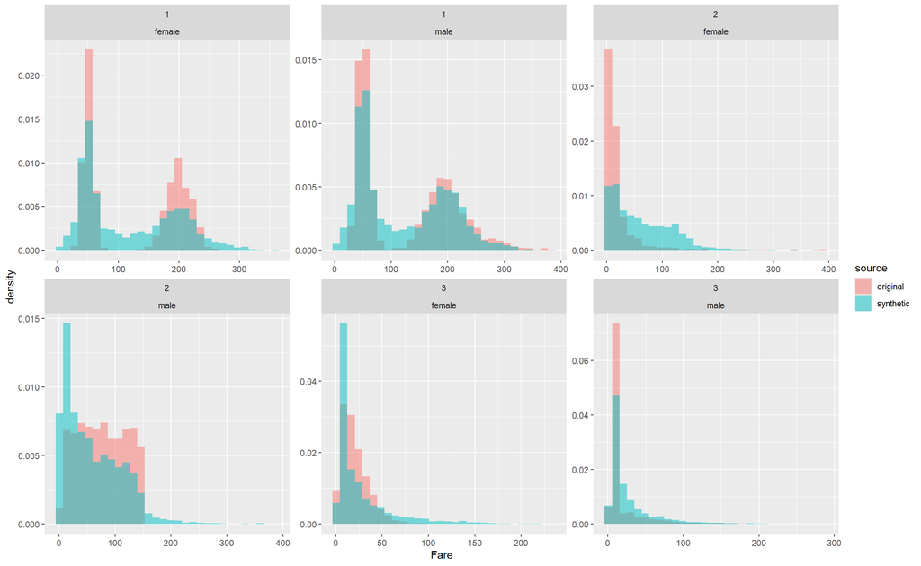

## Experiment 2

- **mtry**: 9
- **family**: truncnorm
- **finite_bounds**: local
- **num_trees**: 100
- **min_node_size**: 100
- **IAE**: 0.336

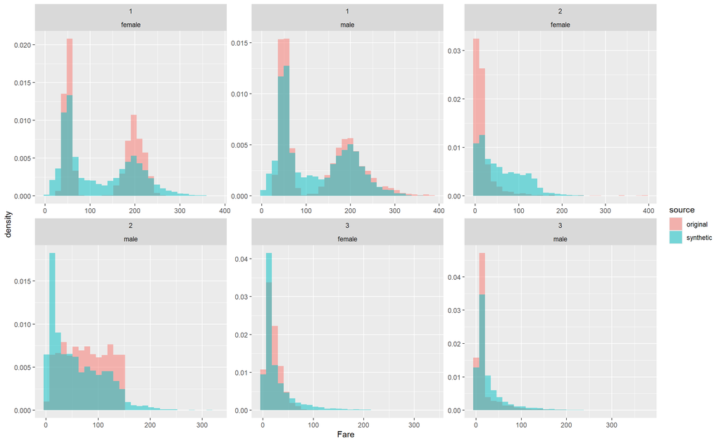

## Experiment 3

- **mtry**: 9
- **family**: truncnorm
- **finite_bounds**: local
- **num_trees**: 500
- **min_node_size**: 20
- **IAE**: 0.336

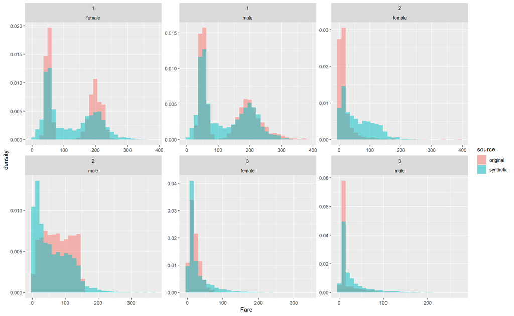

## Experiment 4

- **mtry**: 9
- **family**: truncnorm
- **finite_bounds**: local
- **num_trees**: 500
- **min_node_size**: 100
- **IAE**: 0.336

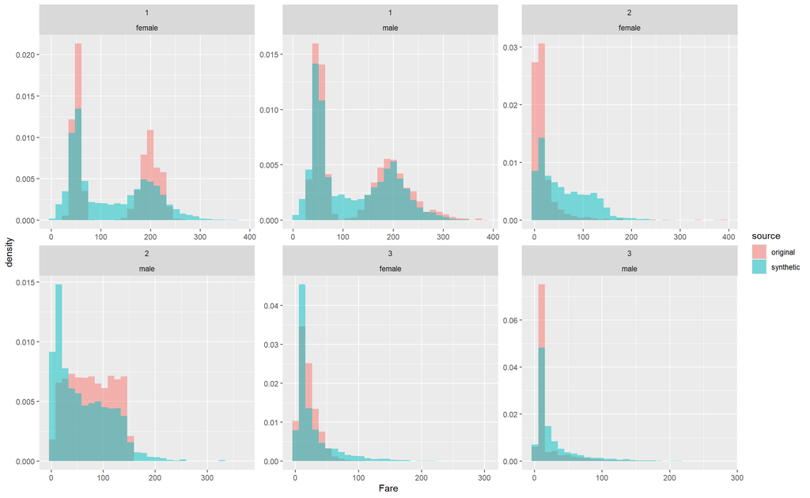

## Experiment 5

- **mtry**: 6
- **family**: truncnorm
- **finite_bounds**: local
- **num_trees**: 100
- **min_node_size**: 20
- **IAE**: 0.344

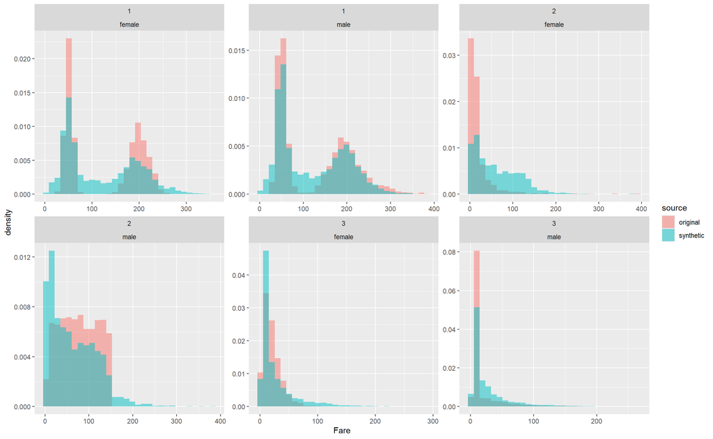

## Experiment 6

- **mtry**: 6
- **family**: truncnorm
- **finite_bounds**: local
- **num_trees**: 100
- **min_node_size**: 100
- **IAE**: 0.344

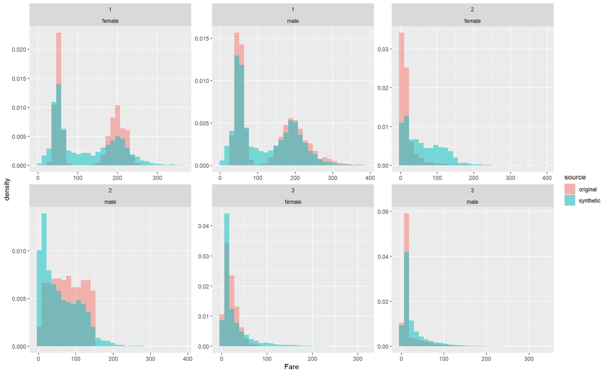

## Experiment 7

- **mtry**: 6
- **family**: truncnorm
- **finite_bounds**: local
- **num_trees**: 500
- **min_node_size**: 20
- **IAE**: 0.344

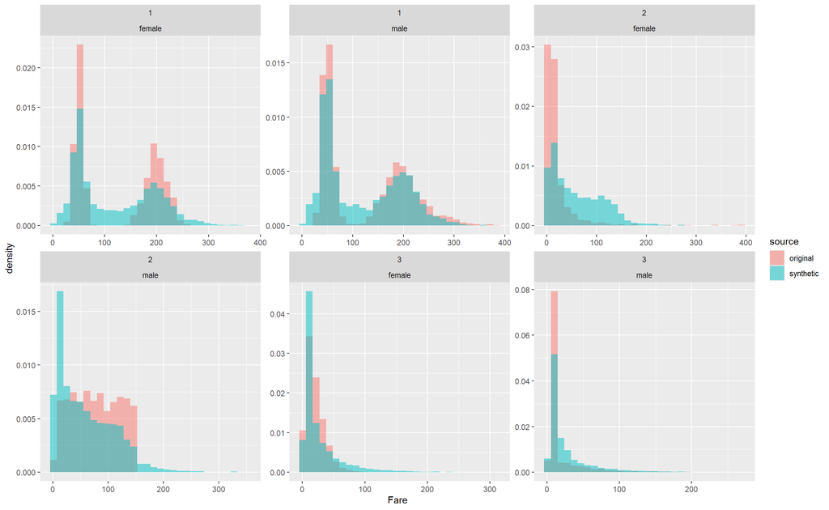

## Experiment 8

- **mtry**: 6
- **family**: truncnorm
- **finite_bounds**: local
- **num_trees**: 500
- **min_node_size**: 100
- **IAE**: 0.344

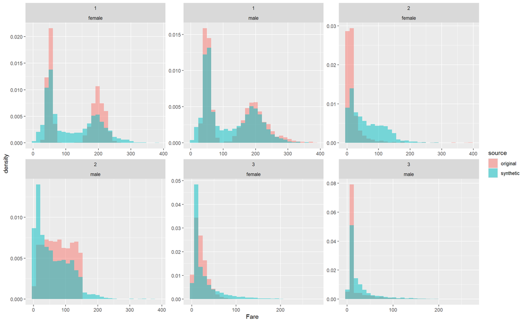

## Experiment 9

- **mtry**: 2
- **family**: truncnorm
- **finite_bounds**: local
- **num_trees**: 100
- **min_node_size**: 20
- **IAE**: 0.383

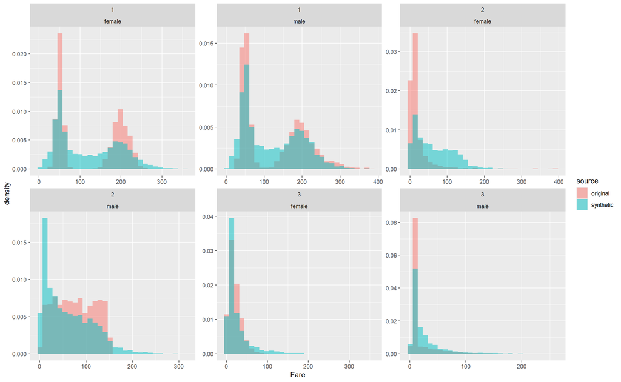

## Experiment 10

- **mtry**: 2
- **family**: truncnorm
- **finite_bounds**: local
- **num_trees**: 100
- **min_node_size**: 100
- **IAE**: 0.383

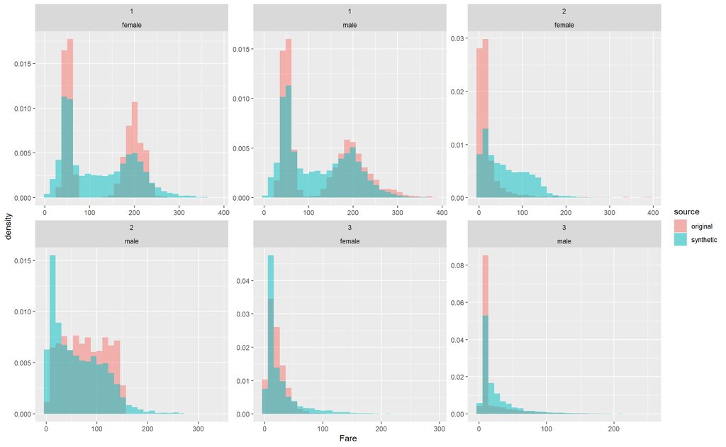

## Experiment 11

- **mtry**: 2
- **family**: truncnorm
- **finite_bounds**: local
- **num_trees**: 500
- **min_node_size**: 20
- **IAE**: 0.383

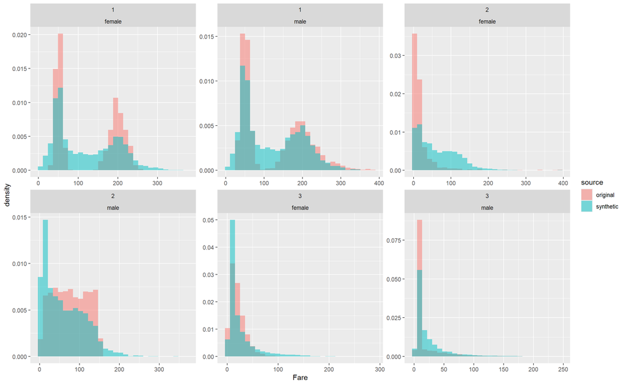

## Experiment 12

- **mtry**: 2
- **family**: truncnorm
- **finite_bounds**: local
- **num_trees**: 500
- **min_node_size**: 100
- **IAE**: 0.383

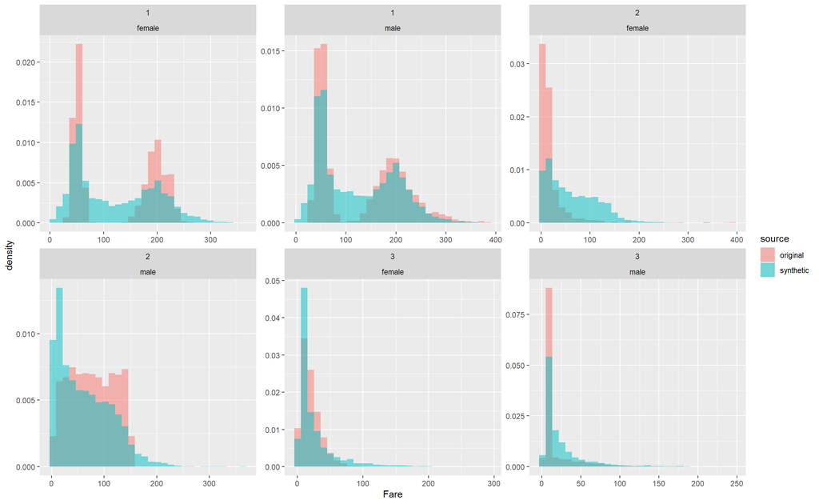

## Experiment 13

- **mtry**: 3
- **family**: truncnorm
- **finite_bounds**: local
- **num_trees**: 100
- **min_node_size**: 20
- **IAE**: 0.421

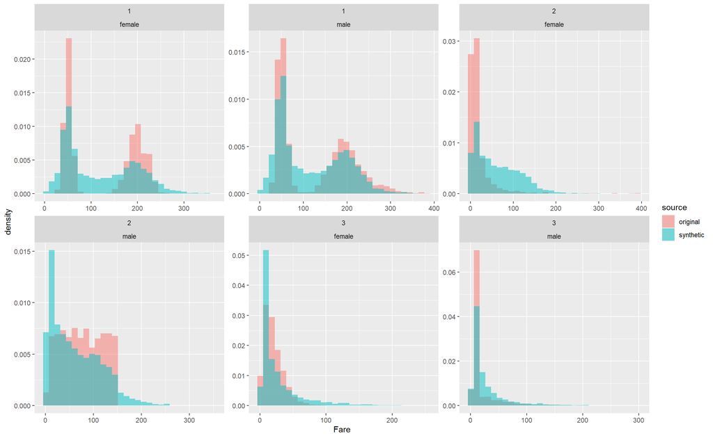

## Experiment 14

- **mtry**: 3
- **family**: truncnorm
- **finite_bounds**: local
- **num_trees**: 100
- **min_node_size**: 100
- **IAE**: 0.421

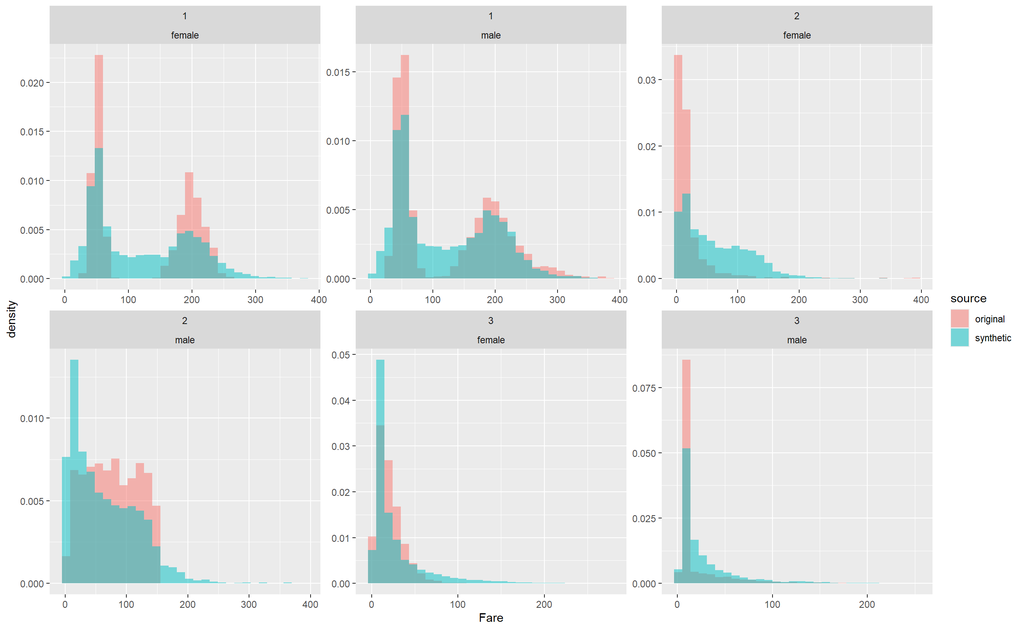

## Experiment 15

- **mtry**: 3
- **family**: truncnorm
- **finite_bounds**: local
- **num_trees**: 500
- **min_node_size**: 20
- **IAE**: 0.421

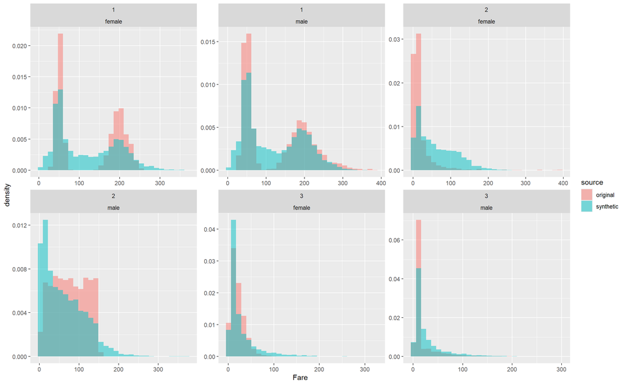

## Experiment 16

- **mtry**: 3
- **family**: truncnorm
- **finite_bounds**: local
- **num_trees**: 500
- **min_node_size**: 100
- **IAE**: 0.421

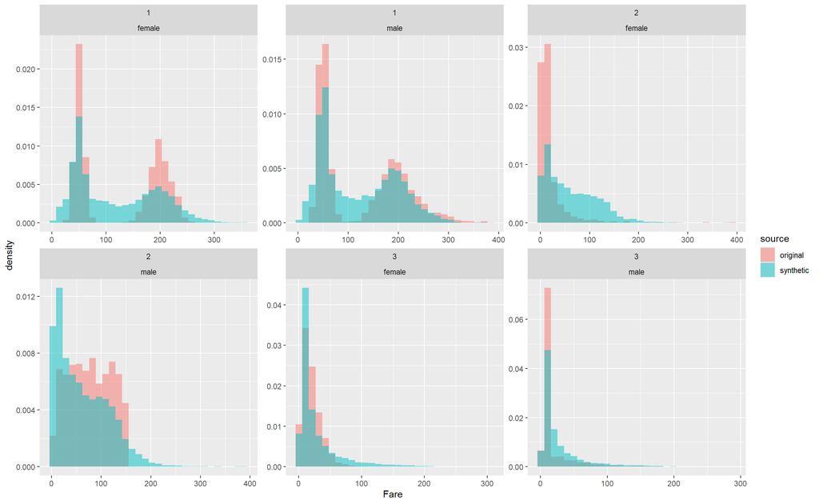